# Introduction to spatialTIME

# Background for Tissue Microarray (TMA) Data

A tissue microarray (TMA) is an array of samples which are obtained by taking a slice of a biopsied FFPE tumor. Each individual slice is referred to as a core. Each core is placed on a TMA and is then stained with multiple antibodies and fluorophores which illuminate when a laser is shined at them with varying wavelengths. The intensity is measured and then a random forest algorithm is used to classify the cells as being positive for a particular marker which allows us to phenotype cells. A schematic of this process is provided in [Figure 1](https://www.mdpi.com/2072-6694/13/12/3031).

# Create Multiplex ImmunoFlourescent (mif) Object

spatialTIME functions use a custom `mif` object which can be created using `create_mif`. The `mif` object has 6 slots storing the:

- Clinical data which must contain:
  - a column whose column name matches one in the sample dataset.
- Sample summary data including counts/percentages of each positive cells for each single or combination of markers and total number of cells for each core. In order to use `create_mif` function this table must contain:
  - a column whose column name matches one in the clinical dataset, and
  - a column whose column name matches one in the spatial list.
- Spatial list (1 per each core):
  - This object should be a list object where each element of the list corresponds to a core and each element should be a $n\times p$ dataframe ($n$ = number of cells) containing:
    1. a column name that matches a column name for the sample file (for merging and potential downstream analysis linking to clinical variables),
    2. `XMin`, `XMax`, `YMin`, and `YMax` which defines the area that a cell occupies which is eventually used to assign a location for each cell with the x-position being the mean of the `XMin` and `XMax` and y-position being the mean of the `YMin` and `YMax`, and
    3. a set of columns that indicate whether a cell is positive to one or multiple markers.
- patient id:
  - a column name used to merge clinical and summary data
- sample_id:
  - a column name used to merge the spatial and summary data
- derived:
  - where all of the plots and spatial clustering measures are stored

We include one example of a clinical and sample dataset which have a total of 229 patients with one core. Out of those 229 samples, only 5 are included in our package.

```r
# Make sure the variable types are the same for deidentified_id and
# deidentified_sample in their corresponding datasets
x <- create_mif(clinical_data = example_clinical %>%
                  mutate(deidentified_id = as.character(deidentified_id)),
                sample_data = example_summary %>%
                  mutate(deidentified_id = as.character(deidentified_id)),
                spatial_list = example_spatial,
                patient_id = "deidentified_id",
                sample_id = "deidentified_sample")

x #prints a summary of how many patients, samples, and spatial files are present
```

```
#> 229 patients spanning 229 samples and 5 spatial data frames were found
```

# Plotting Cores

An individual plot for each core (each sample) is created. Plots can be assigned to an R object, such as within the empty `derived` slot and printed to a PDF if a file name is provided.

```r
mnames_bad <- c("CD3..CD8.","CD3..FOXP3.","CD3..Opal.570..Positive",
                "CD8..Opal.520..Positive","FOXP3..Opal.620..Positive",
                "PDL1..Opal.540..Positive", "PD1..Opal.650..Positive")

# Used to make the legends in both plots below be in same order and use the
# same coloring scheme for the purpose making a common legend

values =  RColorBrewer::brewer.pal(length(mnames_bad), "Accent")
names(values) = mnames_bad

#add an element in the `derived` object position
x<- plot_immunoflo(x, plot_title = "deidentified_sample",  mnames = mnames_bad,
                   cell_type = "Classifier.Label")
bad_names <- x[["derived"]][["spatial_plots"]][[4]] +
  theme(legend.position = 'bottom') +
  scale_color_manual(breaks = mnames_bad,
                     values = values,
                     labels = mnames_bad %>%
                       gsub("..Opal.*", "+", .) %>%
                       gsub("\\.\\.", "+", .) %>%
                       gsub("\\.", "+", .))
mnames_good <- c("CD3..Opal.570..Positive","CD8..Opal.520..Positive",
                 "FOXP3..Opal.620..Positive","PDL1..Opal.540..Positive",
                 "PD1..Opal.650..Positive","CD3..CD8.","CD3..FOXP3.")

x <- plot_immunoflo(x, plot_title = "deidentified_sample", mnames = mnames_good,
                    cell_type = "Classifier.Label")
good_names <- x[["derived"]][["spatial_plots"]][[4]] +
  theme(legend.position = 'bottom') +
  scale_color_manual(breaks = mnames_good,
                     values = values[match(mnames_good, names(values))],
                     labels = mnames_good %>%
                       gsub("..Opal.*", "+", .) %>%
                       gsub("\\.\\.", "+", .) %>%
                       gsub("\\.", "+", .))
x$sample %>% filter(deidentified_sample == 'TMA3_[9,K].tif') %>% select(c(2, 4:15)) %>%
  pivot_longer(cols = 2:13, names_to = 'Marker', values_to = 'Count')
```

```
#> # A tibble: 12 × 3
#>    deidentified_sample Marker                          Count
#>    <chr>               <chr>                           <dbl>
#>  1 TMA3_[9,K].tif      FOXP3 (Opal 620) Positive Cells    34
#>  2 TMA3_[9,K].tif      CD3 (Opal 570) Positive Cells     536
#>  3 TMA3_[9,K].tif      CD8 (Opal 520) Positive Cells      83
#>  4 TMA3_[9,K].tif      PD1 (Opal 650) Positive Cells       5
#>  5 TMA3_[9,K].tif      PDL1 (Opal 540) Positive Cells      1
#>  6 TMA3_[9,K].tif      CD3+ FOXP3+ Cells                  34
#>  7 TMA3_[9,K].tif      CD3+ CD8+ Cells                    68
#>  8 TMA3_[9,K].tif      CD3+ CD8+ FOXP3+ Cells              4
#>  9 TMA3_[9,K].tif      CD3+ PD1+ Cells                     5
#> 10 TMA3_[9,K].tif      CD3+ PD-L1+ Cells                   1
#> 11 TMA3_[9,K].tif      CD8+ PD1+ Cells                     0
#> 12 TMA3_[9,K].tif      CD3+ CD8+ PD-L1+ Cells              0
```

[figure not shown]

```r
gridExtra::grid.arrange(bad_names, good_names, ncol=2)
```

# Estimating the degree of spatial clustering with Count Based Methods

## Univariate

### Count Based Methods

Ripley’s $K$ measures the average number of neighboring cells across each cell. That is, the average (over all cells) number of cells within a specified radius of a cell. Ripley’s $K$ is computed as follows:

$$\hat{K}(r) =
\frac{1}{n(n-1)}\sum_{i=1}^{n}\sum_{j\neq i}w_{ij}{\bf 1}{(d(x_i,x_j)\le
r)},$$

where $r$ is the specified radius, $d(x_i,x_j)$ is the distance between the $i^{th}$ and $j^{th}$ cell, ${\bf 1}_A$ is indicator function of event $A$, and $w_{ij}$ is the weights that are assigned for border corrections. The expected value of $\hat{K}(r)$ is $\pi r^2$, thus $\hat{K}$ is expected to grow as a quadratic function of $r$.

There are several edge corrections. Our studies have included a small number of cells and we recommend using the ‘isotropic’ or ‘translational’ edge correction, as opposed to the ‘border’ edge correction. The main goal of the edge correction is to account for the fact that there are unobserved points outside of the region, and the assumption is that the location of these cells has the same distribution as the study region. An excellent description of these corrections are provided [here](https://book.spatstat.org/sample-chapters/chapter07.pdf).

### Distance Based Measures

The distribution of the nearest neighbor distances, $\hat{G}(r)$, can be studied and is computed by

$$\hat{G}(r) =
\frac{1}{n}\sum_{i=1}^{n}{\bf 1}(\min_{j}(\{d(x_i,x_j)\}\le
r),$$

which is interpreted as the proportion of cells whose distance to its nearest neighbor is less than $r$. Notice that there is not a weighting factor for each pair of points as we saw above. The edge correction in these methods, reduced sample (`rs`) and Hanisch (`han`), simply have different cell inclusion conditions. The reduced sample correction is similar to the border correction for count based methods, where the middle chunk of the area of interest is studied. The Hanisch border correction leaves out points whose $k^{th}$ neighbor can not be in the area of interest. For more information about these border corrections, see the following [article](https://www.routledgehandbooks.com/pdf/doi/10.1201/b16195-4).

## Need for Permutations

An underlying assumption used for many spatial clustering metrics is that the cells are randomly distributed across the region, no evidence of clustering or repulsion, and that the cell intensity is constant across the entire region. This assumption is the so-called complete spatial randomness (CSR). Damage can occur to tissue cores due to how they are collected. This damage can lead to rips and tears in the cores which results in regions where it appears that cells are not located and is not actually the case. Due to these violations of the CSR assumption, the theoretical estimate for CSR may not be accurate. To address this the cell positivity can be permuted across all observed locations and the permutation distribution of $K$, $L$, $M$, and $G$ is a core specific measure of CSR than theoretical. Also, with the permutations of CSR we are able to determine whether the observed clustering is significant by lying above or below a 95% of permuted CSR estimates.

## Calculating Exact CSR

The product of running all possible permutations of Ripley’s K and bivariate Ripley’s K for cells on a TMA core or an ROI spot is simply the result of running Ripley’s K or bivariate Ripley’s K on all cells ignoring their marks. This allows us to determine the exact degree of clustering that are can use for associations with survival or other clinical variables.

# Implementation

## Univariate Count-Based Methods

The `ripleys_k` function reports a permuted and theoretical estimate of CSR, the observed value for $K$ and the full permutation distribution of $K$ using `permute = TRUE, keep_permutation_distribution = TRUE`.

Currently, the number of permutations is 10, but this should be increased to at least 100 for a more reliable estimate of the mean.

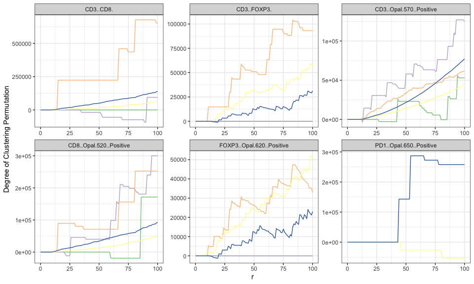

```r
x <- ripleys_k(mif = x, mnames = mnames_good,
               num_permutations = 10, method = "K",
               edge_correction = 'translation', r_range = 0:100,
               permute = TRUE,
               keep_permutation_distribution = FALSE, overwrite = TRUE, workers = 1)

# This will keeps the colors in evx$ery plot for the remainder of the vignette compatible
values = RColorBrewer::brewer.pal(length(unique(x$derived$univariate_Count[[x$sample_id]])), "Accent")
names(values) = unique(x$derived$univariate_Count$deidentified_sample)

x$derived$univariate_Count  %>%
  filter(Marker != 'PDL1..Opal.540..Positive') %>%
  ggplot(aes(x = r, y = `Degree of Clustering Permutation`)) +
  geom_line(aes(color = get(x$sample_id)), show.legend = FALSE) +
  facet_wrap(Marker~., scales = 'free') + theme_bw() +
  scale_color_manual(values = values)
```

We can also run using the exact CSR approach which is faster and produces a more accurate Degree of clustering.

```r
x <- ripleys_k(mif = x, mnames = mnames_good,
               num_permutations = 10, method = "K",
               edge_correction = 'translation', r_range = 0:100,
               permute = FALSE,
               keep_permutation_distribution = FALSE, overwrite = TRUE, workers = 1)
```

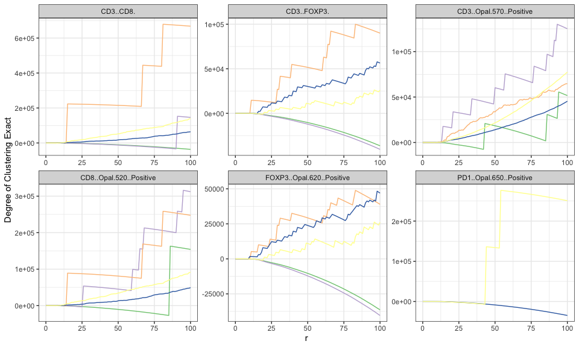

```r
# This will keeps the colors in evx$ery plot for the remainder of the vignette compatible
values = RColorBrewer::brewer.pal(length(unique(x$derived$univariate_Count[[x$sample_id]])), "Accent")
names(values) = unique(x$derived$univariate_Count$deidentified_sample)

x$derived$univariate_Count  %>%
  filter(Marker != 'PDL1..Opal.540..Positive') %>%
  ggplot(aes(x = r, y = `Degree of Clustering Exact`)) +
  geom_line(aes(color = get(x$sample_id)), show.legend = FALSE) +
  facet_wrap(Marker~., scales = 'free') + theme_bw() +
  scale_color_manual(values = values)
```

Positive values for degree of cluster when using `method = 'K'` indicates evidence of spatial clustering, while negative values correspond to spatial regularity. We can also observe that the `permute = TRUE` method is slightly more jagged in it’s curve smoothness than the `permute = FALSE` method (FOXP3 negative curves in particular).

## Sensitivity of r

There is no clear way to select which value of $r$ to use for a particular analysis. Below we illustrate how the degree of clustering can change with the value of $r$. Notice that for values of $r > 20$ that there is very little difference in the ordering between the samples (though the degree of spatial clustering can changes dramatically), while very small values $r$ would have different results. It’s typically recommended to pick an $r$ in a region that is of interest (small scale or large scale clustering) where there is higher variation in the Degree of Clustering values between samples.

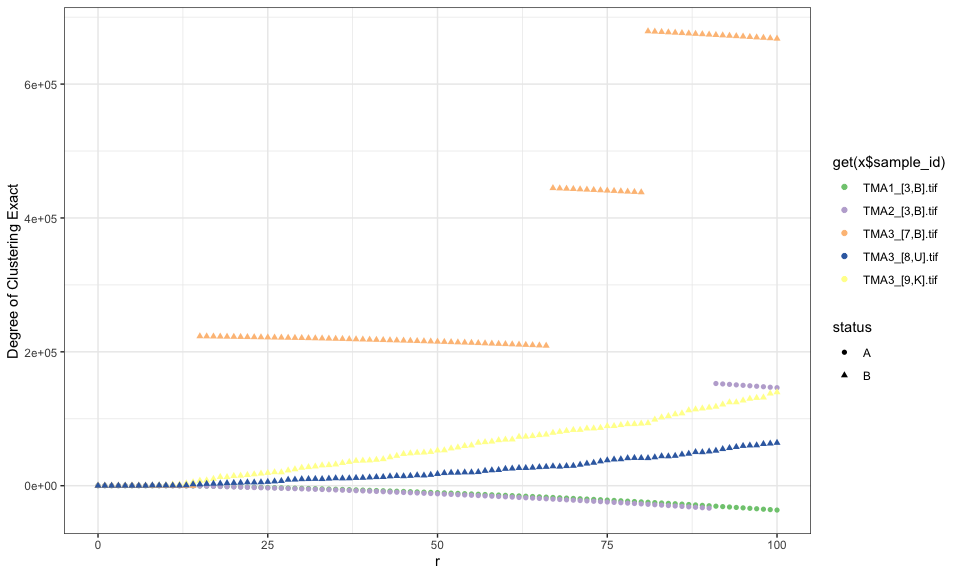

```r
x$derived$univariate_Count %>%
  filter(Marker == 'CD3..CD8.') %>%
  inner_join(x$clinical,.) %>%
  ggplot(aes(shape = status, y = `Degree of Clustering Exact`, x =r)) +
  geom_point(aes(color = get(x$sample_id))) +
  theme_bw() + scale_color_manual(values = values)
```

## Bivariate Count-Based Methods

In the univariate case, we consider each cell of a single cell type and center circles around each cell (reference cell). In the bivariate case, we are interested in how many cells of Type 1 (Counted) are clustered in proximity to Type 2 (Anchor). Here the circles are centered around cell of Type 2 and then the cells of Type 1 are counted. Similar to univariate Ripley’s K, we will run 10 permutations to get an average permuted CSR value.

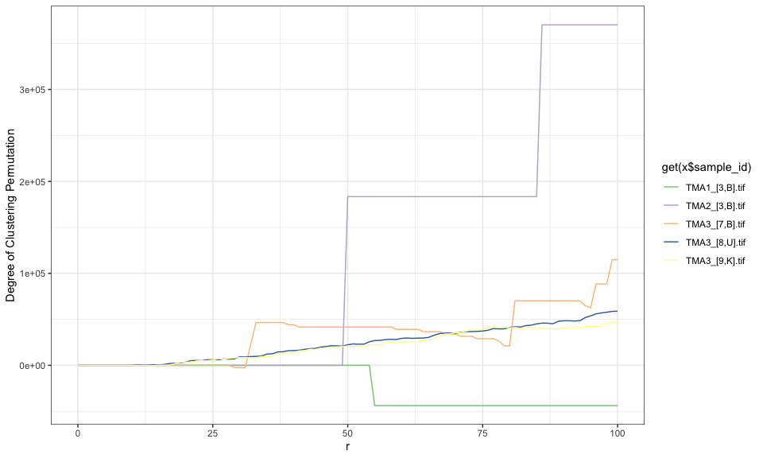

```r
x <- bi_ripleys_k(mif = x, mnames = mnames_good,
                  num_permutations = 10,
                  permute=TRUE,
                  edge_correction = 'translation', r_range = 0:100,
                  keep_permutation_distribution = FALSE, workers = 1)

x$derived$bivariate_Count  %>%
  filter(Anchor == 'CD3..FOXP3.',
         Counted == 'CD3..CD8.') %>%
  ggplot(aes(x = r, y = `Degree of Clustering Permutation`)) +
  geom_line(aes(color = get(x$sample_id)), show.legend = TRUE) +
  theme_bw() + scale_color_manual(values = values)
```

We can also do the same as with the univariate Ripley’s K and set `permute = FALSE` in order to get the exact CSR estimate and degree of clustering.

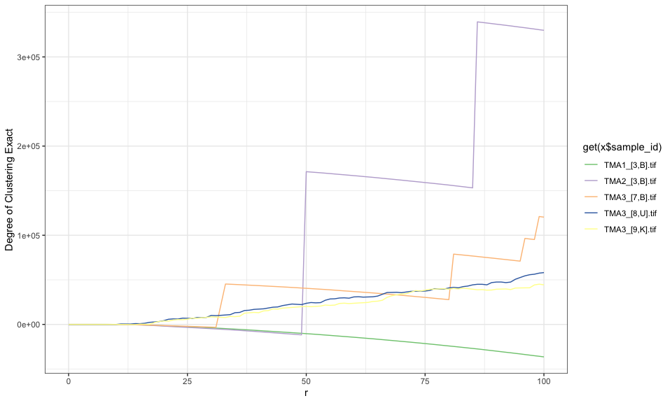

```r
x <- bi_ripleys_k(mif = x, mnames = mnames_good,
                  num_permutations = 10,
                  permute=FALSE,
                  edge_correction = 'translation', r_range = 0:100,
                  keep_permutation_distribution = FALSE,
                  overwrite = TRUE, workers = 1)

x$derived$bivariate_Count  %>%
  filter(Anchor == 'CD3..FOXP3.',
         Counted == 'CD3..CD8.') %>%
  ggplot(aes(x = r, y = `Degree of Clustering Exact`)) +
  geom_line(aes(color = get(x$sample_id)), show.legend = TRUE) +
  theme_bw() + scale_color_manual(values = values)
```

## Univariate Nearest-Neighbor Methods

Currently, the number of permutations is 10, but this should be increased to at least 100 for a more reliable estimate of the mean.

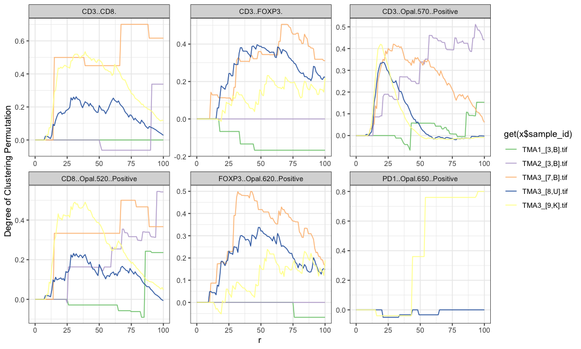

```r
x <- NN_G(mif = x, mnames = mnames_good, num_permutations = 10,
                edge_correction = 'rs', r = 0:100, workers = 1)

x$derived$univariate_NN  %>%
  filter(Marker != 'PDL1..Opal.540..Positive') %>%
  ggplot(aes(x = r, y = `Degree of Clustering Permutation`)) +
  geom_line(aes(color = get(x$sample_id))) +
  facet_wrap(Marker~., scales = 'free') + theme_bw() +
  scale_color_manual(values = values)
```

## Bivariate Nearest-Neighbor Methods

The interpretation of the bivariate nearest neighbor distribution is similar to bivariate Ripley’s $K$, in that we are measuring the degree of clustering of one cell type with respect to another. The actual value of degree of clustering is interpreted in the same manner as the univariate nearest neighbor distribution.

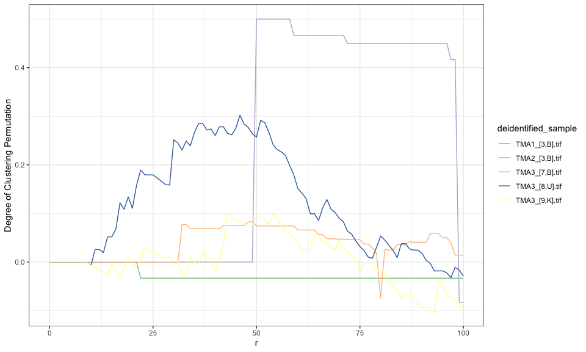

```r
x <- bi_NN_G(mif = x, mnames = c("CD3..CD8.", "CD3..FOXP3."), num_permutations = 10,
               edge_correction = 'rs', r = 0:100, workers = 1, overwrite = TRUE)

x$derived$bivariate_NN  %>%
  filter(Anchor == 'CD3..FOXP3.') %>%
  ggplot(aes(x = r, y = `Degree of Clustering Permutation`)) +
  geom_line(aes(color = deidentified_sample), show.legend = TRUE) +
  theme_bw() +  scale_color_manual(values = values)
```

## Permutation Distribution

For this example, we use the same data used above for plotting cell locations. Now we only focus on the same TMA core and only focus on CD3 positive cells. In this particular TMA core, we can see that the overall cell distribution is not uniform (i.e. there are many regions where cells do not occur). Also notice, that there the CD3+ cells occur mostly in two places, thus we suspect that the degree of clustering is quite large in this TMA core.

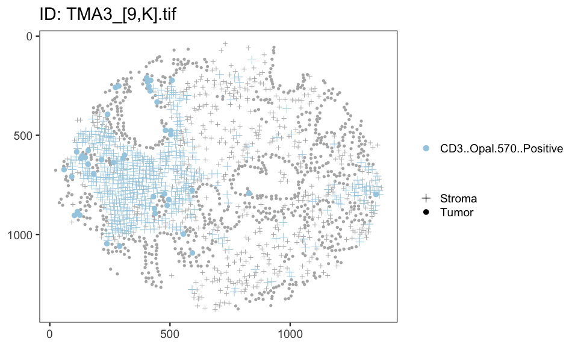

Cell locations for a particular TMA core where the blue cells are CD3+ cells and the grey cells are CD3- cells. Notice that there is a much larger quantity on the left than the right half indicating that there is some clustering occuring.

```r
x <- plot_immunoflo(x, plot_title = "deidentified_sample", mnames = mnames_good[1],
                    cell_type = "Classifier.Label")
x[["derived"]][["spatial_plots"]][[4]]
```

Below is an example that shows how to select a single value for $r$, and how one can visualize the permutation distribution as it relates to the theoretical and observed values. Here we plot the permutation distribution for the CD3+ cells with $r = 50$. Note that the range of $r$ that is included must contain 0 and the output will not include the degree of clustering at $r = 0$, which is 0 for $K$ and $L$, and $\infty$ for $M$. Notice that the theoretical value is smaller than all 100 values from the permutation distribution.

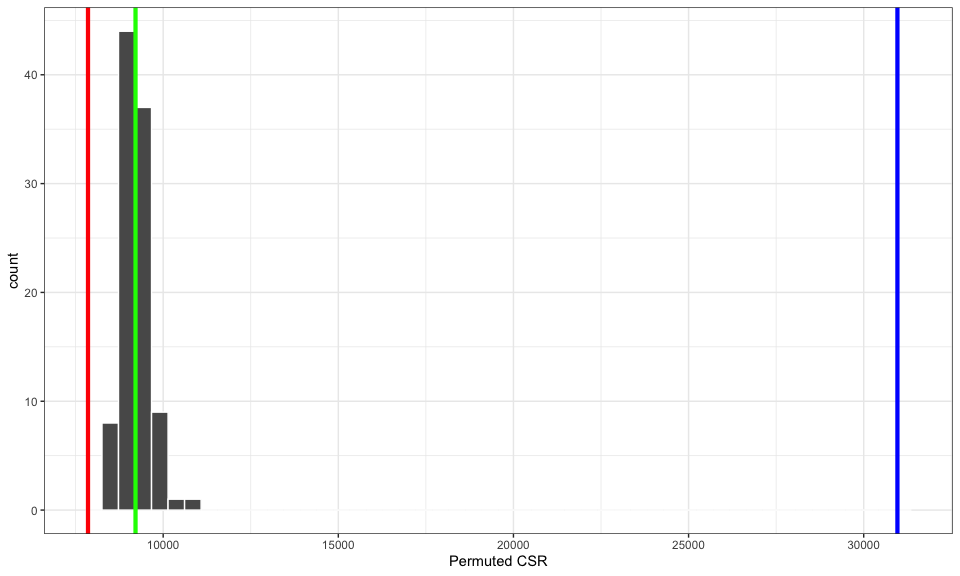

Histogram displaying how much the permuted estimates of K (100 permutations) can vary. This also illustrates how different the permutation distribution and its mean (green vertical line) can be from the theoretical value (red vertical line) or observed value (blue vertical line). Lastly, this plot confirms what we see visually above in that the CD3+ cells are not uniformly distributed throughout this slide, but clustered.

```r
x <- ripleys_k(mif = x, mnames = mnames_good[1], num_permutations = 100,
               edge_correction = 'translation', r = c(0,50),
               permute = TRUE,
               keep_permutation_distribution = TRUE, workers = 1, overwrite = TRUE)

#Computed the mean of the permutation distribution for a particular image
perm_mean  = x$derived$univariate_Count %>%
  filter(deidentified_sample == 'TMA3_[9,K].tif',
         r == 50)  %>%
  summarize(`Permuted CSR` = mean(`Permuted CSR`)) %>%
  unlist()

x$derived$univariate_Count %>%
  filter(deidentified_sample == 'TMA3_[9,K].tif',
         r == 50) %>%
  ggplot(aes(x = `Permuted CSR`)) +
  geom_histogram(color = 'white', bins = 50) +
  geom_vline(aes(xintercept = `Theoretical CSR`), color = 'red', size = 1.5) +
  geom_vline(aes(xintercept = `Observed K`), color = 'blue', size = 1.5) +
  geom_vline(xintercept = perm_mean, color = 'green', size = 1.5) +
  theme_bw()
```

# Subsetting by Compartment

Many studies may only interested in the spatial location within the tumor or stroma compartment instead of studying all cells. By using the `subset_mif` function which requires the column (Classifier.Label in our example) and label of cells desired (Tumor here meaning that we want to focus our analysis on only the tumor compartment).

```r
x_tumor = subset_mif(x, classifier = 'Classifier.Label', level = 'Tumor', markers = mnames_good)

table(x$spatial[[1]]$Classifier.Label)
```

```
#>
#> Stroma  Tumor
#>    192   3611
```

```r
table(x_tumor$spatial[[1]]$Classifier.Label)
```

```
#>
#> Tumor
#>  3611
```

# Follow-up Analysis

Once the degree of spatial clustering has be computed, questions like “Is the degree of clustering for CD3+ cells between two populations different? (t-test) or”Is the pattern of degree of clustering different between two populations?” (can be checked visually with a heatmap) may be answered.

Due to space constraints, there are only 5 TMA cores included in the example dataset. Thus, visualization is included and no statistical analysis will be conducted. With this very limited number of samples it does look like there is some evidence that CD3+CD8+, CD8+, and FOXP3+ are more clustered in patients from status B than status A, while the CD3+ cells are less clustered in patients with status B.

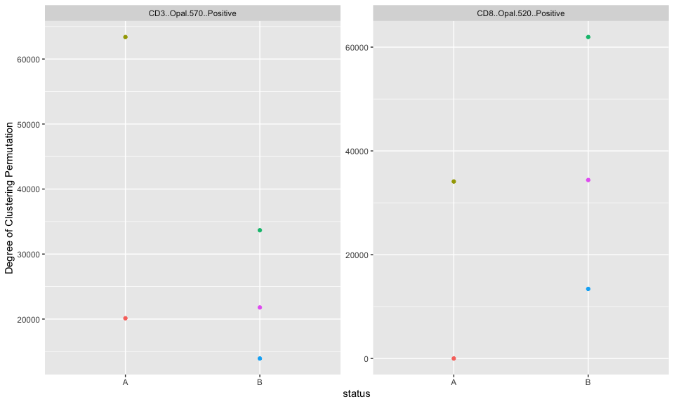

Scatter plots showing the difference in degree of spatial clustering for CD3+, and CD8+ cells. These markers were selected since all 5 examples spatial files had at least 2 to these cells.

```r
x <- ripleys_k(mif = x, mnames = mnames_good, num_permutations = 10,
               edge_correction = 'translation', r = c(0,50), permute = T,
               keep_permutation_distribution = FALSE, workers = 1, overwrite = TRUE)

inner_join(x$clinical, x$derived$univariate_Count) %>%
  filter(grepl('CD3..O|CD8..O', Marker), r == 50) %>%
  ggplot(aes(x = status, y = `Degree of Clustering Permutation`)) +
  geom_point(aes(color = deidentified_sample), show.legend = FALSE) +
  facet_wrap(Marker ~., scales = 'free')
```

```r
Rip_K_df = x$derived$univariate_Count %>%
  filter(!(Marker %in% c('PDL1..Opal.540..Positive',
                         'CD3..FOXP3.',
                         'PD1..Opal.650..Positive')), r == 50) %>%
  select(deidentified_sample, Marker, `Degree of Clustering Permutation`) %>%
  pivot_wider(names_from = deidentified_sample, values_from = `Degree of Clustering Permutation`,
              id_cols = Marker)
Rip_K_matrix = Rip_K_df %>%
  ungroup() %>%
  select(-Marker) %>%
  as.matrix()

rownames(Rip_K_matrix) = Rip_K_df$Marker

annotation = inner_join(x$clinical, x$derived$univariate_Count) %>%
  select(deidentified_sample, status) %>%
  filter(!duplicated(.)) %>%
  data.frame()
```

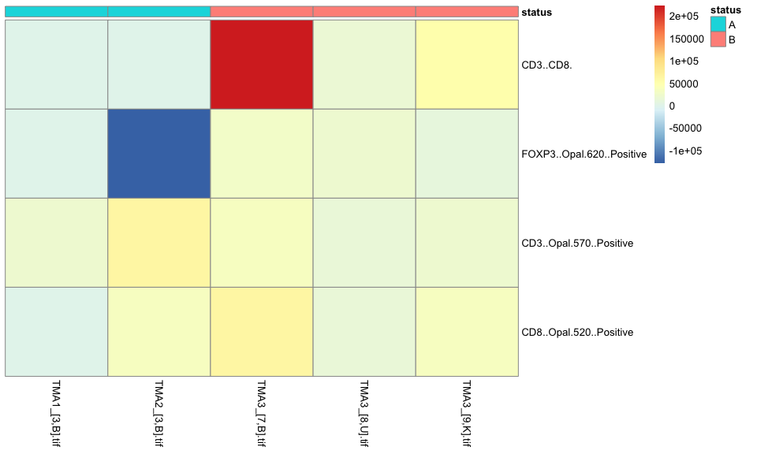

Heatmaps showing a potential descriptive visualization for identifying difference patterns within multiple markers across different populations.

```r
rownames(annotation) = annotation$deidentified_sample

annotation = annotation %>%
  select(status)

pheatmap(Rip_K_matrix, treeheight_row = 0, treeheight_col = 0,
                   cluster_cols = FALSE, annotation = annotation)
```

# Using Custom Cell Locations

If `xloc` and `yloc` are set as `NULL`, when computing spatial clustering than the cell location is the center of the cell (x-coordinate is the average of `XMin` and `XMax`, and y-coordinate is the average of `YMin` and `YMax`). If you desire to use custom points, this is possible by identifying which column the new coordinates are from. Here were compute Ripley’s $K$ with the minimum coordinate of x and y.

```r
x <- ripleys_k(mif = x, mnames = mnames_good[1], num_permutations = 100,
               edge_correction = 'translation', r = c(0,50),permute = TRUE,
               keep_permutation_distribution = TRUE, workers = 1, overwrite = TRUE,
               xloc = 'XMin', yloc = 'YMin')
```